# text_lab

Josephine Johannes

10/20/21

Congratulations you’ve successfully transferred from being a NBA ‘quant’ scout to a consultant specializing in US national sentiment! You’ve been hired by a non-profit in secret to track the level of support nationally and regionally for the Climate Change issues. The goal is to get a general idea of patterns associated with articles being written on the broad topic of Climate Change (you can also choose to select a sub-topic). In doing so your data science team has decided to explore periodicals from around the country in a effort to track the relative positive or negative sentiment and word frequencies. Luckily you have access to a world class library search engine call LexusNexus (NexusUni) that provides access to newspapers from around the country dating back decades. You’ll first need to decided what words you want to track and what time might be interesting to begin your search.

Your main goal (and the goal of all practicing data scientists!) is to translate this information into action. What patterns do you see, why do you believe this to be the case? What additional information might you want? Be as specific as possible, but keep in mind this is an initial exploratory effort…more analysis might be needed…but the result can and should advise the next steps you present to the firm.

## What we’re tracking

Essentially, we used the phrase “Climate Change” for various regions to track sentiment in 2021.

#### Loading Essential Libraries

## MidAtlantic Region

The text document was downloaded from the Lexis Nexis database. 30 of the most recent newspapers in Pennsylvania, written by the Pittsburgh Post-Gazette, were compiled as one RTF file and converted into an text file.

#### Load in Mid Atlantic Region File

```r
# import data from compiled newspaper reading
mid_atl <- read_lines("MidAtlanticRegion.txt")
# make mid_atl into a tibble data structure
mid_atl <- tibble(mid_atl)
```

#### Word Frequencies

1. The first step in the process is finding the frequency of words per region by tokenizing the document.

```r
#change the data frame variables in mid_atl$mid_atl character types
mid_atl$mid_atl <- as.character(mid_atl$mid_atl)

# tokenize mid_atl by word, take out common words like a, and count the number of words
mid_atl <- mid_atl %>%
  unnest_tokens(word, mid_atl) %>%
  anti_join(stop_words) %>% count(word, sort=TRUE)
```

#### Sentiment Analysis

2. Using the word frequency from step 1, we use lexicons that help to classify the words in the documents using sentiment.

```r
mid_atl_sentiment_affin <- mid_atl %>% inner_join(get_sentiments('afinn'))
mid_atl_sentiment_nrc <- mid_atl %>% inner_join(get_sentiments('nrc'))
mid_atl_sentiment_bing <- mid_atl %>% inner_join(get_sentiments('bing'))
table(mid_atl_sentiment_bing$sentiment)
```

```
##
## negative positive
##      336      231
```

```r
table(mid_atl_sentiment_nrc$sentiment)
```

```
##
##        anger anticipation      disgust         fear          joy     negative
##          148          173           94          185          112          328
##     positive      sadness     surprise        trust
##          440          135           85          254
```

From the nrc lexicon, it would seem that most articles have a positive sentiment on climate change and the next highest sentiment would be negative.

#### Plot Sentiment

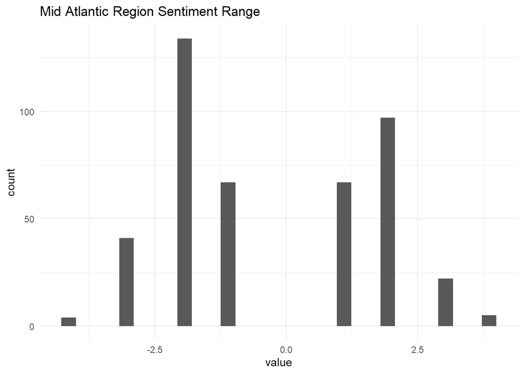

```r
ggplot(data = mid_atl_sentiment_affin, aes(x=value))+geom_histogram()+ggtitle("Mid Atlantic Region Sentiment Range")+theme_minimal()
```

From the histogram, it seems that there are more words that have a negative sentiment, compared to the amount of words with a positive sentiment. This could be related to how Pennsylvania had recently been hit by Hurricane Ida and is still in the process of recovering from the natural disaster. Governor Tim Wolf also announced the Pennsylvania Climate Action Plan 2021 which may have increased the amount of articles released recently.

#### Another way to analyze Sentiment

Here we use the ggplot package

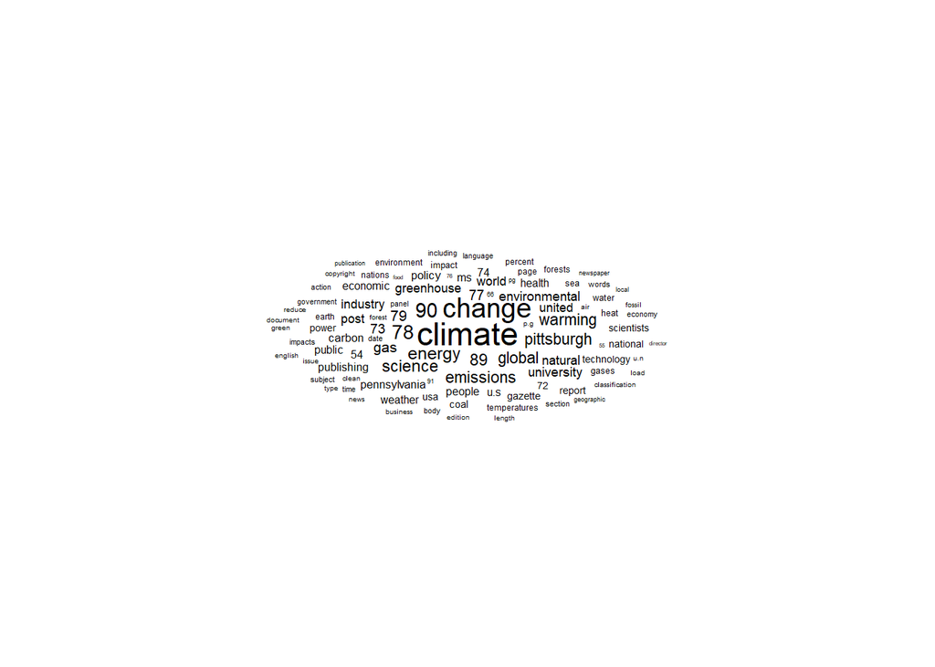

```r
set.seed(42)
ggplot(mid_atl[1:100,], aes(label = word, size = n))+geom_text_wordcloud()+theme_minimal()
```

#### Results:

There are frequent words in the documents that include science, emissions, global, energy, warming, natural, and university, excluding the words climate and change. I think it would be a good idea to look at different universities and see the overall support for climate change there as well as bigger urban areas. I would say that Pittsburgh is a big urban area that uses a lot of energy so there could be negative sentiment due to the energy consumption in the city. It seems like there has been a correlation with the science as evidence for climate change, so a more negative sentiment could also be seen in scholarly literature.

## NorthEast Region

The text document was downloaded from the Lexus Nexus database. 30 of the most recent newspapers written by the Bangor Daily News in Maine were compiled as one RTF file and converted into an text file.

#### Load in NorthEast Region File

```r
# import data from compiled newspaper reading
north <- read_lines("NorthEastRegion.txt")
# make north into a tibble data structure
north <- tibble(north)
```

#### Word Frequencies

1. The first step in the process is finding the frequency of words per region.

```r
#change the data frame variables in north$north character types
north$north <- as.character(north$north)

north <- north %>%
  unnest_tokens(word, north) %>%
  anti_join(stop_words) %>% count(word, sort=TRUE)
```

#### Sentiment Analysis

```r
north_sentiment_affin <- north %>% inner_join(get_sentiments('afinn'))
north_sentiment_nrc <- north %>% inner_join(get_sentiments('nrc'))
north_sentiment_bing <- north %>% inner_join(get_sentiments('bing'))
table(north_sentiment_bing$sentiment)
```

```
##
## negative positive
##      272      181
```

```r
table(north_sentiment_nrc$sentiment)
```

```
##
##        anger anticipation      disgust         fear          joy     negative
##          103          166           67          130           90          270
##     positive      sadness     surprise        trust
##          351          103           69          209
```

From the nrc sentiment, it seems that the emotion most felt in the articles is positive and then the second highest emotion would be negative emotions.

#### Plot Sentiment

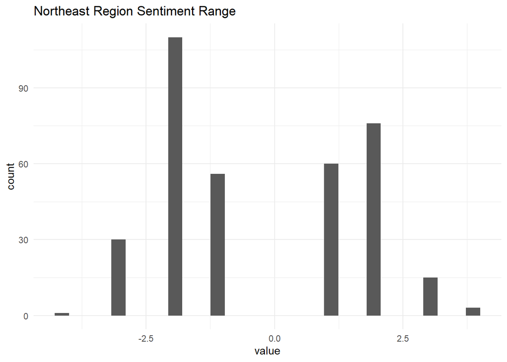

```r
ggplot(data = north_sentiment_affin, aes(x=value))+geom_histogram()+ggtitle("Northeast Region Sentiment Range")+theme_minimal()
```

From the graph, it seems like there are more words that have a negative sentiment compared to those with a positive sentiment.

#### Another way to analyze Sentiment

Here we use the ggplot package

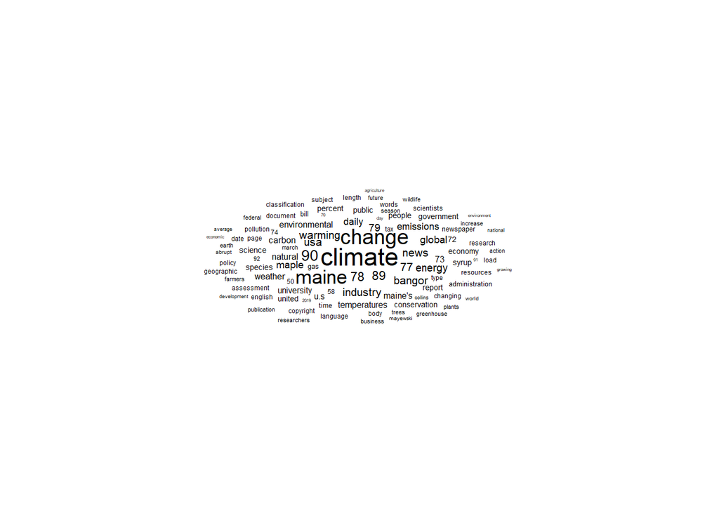

```r
set.seed(42)
ggplot(north[1:100,], aes(label = word, size = n))+geom_text_wordcloud()+theme_minimal()
```

#### Conducting the tf-idf

```r
mid_atl_raw <- as.tibble(read_lines("MidAtlanticRegion.txt"))
north_raw <- as.tibble(read_lines("NorthEastRegion.txt"))
data_prep <- function(x,y,z){
  i <- as_tibble(t(x))#transposing the data set
  ii <- unite(i,"text",y:z,remove = TRUE,sep = "")
}
mid_atl_bag <- data_prep(mid_atl_raw,'V1','V2088')
```

[output not shown]

[output not shown]

```r
north_bag<- data_prep(north_raw,'V1','V1979')
region <- c("MidAtlantic Region","NorthEast Region")
tf_idf_text <- tibble(region,text=t(tibble(mid_atl_bag,north_bag,.name_repair = "universal")))
```

```
## * text -> text...1
## * text -> text...2
```

```r
View(tf_idf_text)
word_count <- tf_idf_text %>%
  unnest_tokens(word, text) %>%
  anti_join(stop_words) %>%
  count(region, word, sort = TRUE)
View(word_count)
total_words <- word_count %>%
  group_by(region) %>%
  summarize(total = sum(n))
region_words <- inner_join(word_count, total_words)
region_words <- region_words %>%
  bind_tf_idf(word, region, n)
View(region_words)
```

### Recommendations

To look more specifically at the various stakeholders involved in climate change for the overall regions, I would recommend looking into universities as well as their faculty and carbon plants for each region respectively. Although there might be a higher negative sentiment in those areas, it would be interesting to find out the context as to why there is such a negative sentiment. In more recent news, I think more studies have been conducted on climate change and how the world is losing the necessary sources to survive at a faster pace than calculated, which leads into emotions like fear and anger. Overall, it would be important to look at the different stakeholders.